# Final Lab

Author

Cole Stanford and JP Killmond

## The Data

For this lab, we will be using the Wooldridge bwght dataset. It is a cross-sectional dataset often used in introductory econometrics to study how family, parental, and pregnancy-related factors are associated with infant birth weight. The dataset contains 1388 observations and 14 variables. Each observation represents one child, with information on its birth weight. Additionally, each observation has data on family information that could contribute to the baby’s birth weight, including income, parental education, birth order, sex, race, and the number of cigarettes smoked a day by the mother.

The data is in a .RData so it is easy to access. The data includes a data frame named `data`, which contains the information described above. It also includes a data frame named `desc`, which serves as a brief data dictionary.

The full data dictionary for this dataset can be accessed here: [Data Dictionary](https://justinmshea.github.io/wooldridge/reference/bwght.html)

### Question 0: Data & Package Loading

**Load appropriate packages and download and load the appropriate `bwght` dataset. The dataset is available [here](https://www.cengage.com/cgi-wadsworth/course_products_wp.pl?fid=M20b&product_isbn_issn=9781111531041). You will need to extract the files in the downloaded .zip folder and move the only necessary .Rdata file to your working directory for this lab.**

```r
# Data
load("bwght.RData")
```

```r
# Packages
library(tidyverse)
library(knitr)
library(gt)
library(broom)
```

### Question 1: Data Cleansing

**Using relevant dplyr verbs in a single pipeline, do the following: 1) create a new variable reflecting the affordability relationship between family income and state cigarette prices, 2) remove `lbwght`, `bwghtlbs`, `packs`, and `lfaminc` from the dataset, 3) create a new variable fam_educ which is the sum of the mother’s and father’s education**

```r
data <- data |>
  mutate(affordability = faminc / cigprice) |>
  select(faminc: cigs) |>
  mutate(fam_educ = motheduc + fatheduc)
```

### Question 2: Factor and Dummy Variable Creation Using case_when()

**Create a new factor variable `cig_level`, which reflects the number of cigarettes smoked by the mother. 0 is “none”, 1-3 is “low”, 4-10 is “moderate”, 11-20 is “high”, and 21+ is “very high. Additionally, create a dummy variable called `treat`. This will be 0 if the mother doesn’t smoke and 1 if the mother does smoke. Do this in one pipeline.”**

```r
data <- data |>
  mutate(cig_level = factor(case_when(cigs == 0 ~ "zero",
                               cigs <= 3 ~ "low",
                               cigs <= 10 ~ "moderate",
                               cigs <= 20 ~ "high",
                               .default = "very high")),
         treat = case_when(cigs == 0 ~ 0,
                           .default = 1))
```

### Question 3: Table Creation

**Create a table that shows, for each level of `cig_level`, a count of individuals and the average `bwght`, `motheduc`, `fatheduc`, and `cigprice`. Order the table from highest to lowest `bwght`.**

```r
data |>
  group_by(cig_level) |>
  summarize(n(),
            av_bwght = mean(bwght, na.rm = TRUE),
            av_motheduc = mean(motheduc, na.rm = TRUE),
            av_fatheduc = mean(fatheduc, na.rm = TRUE),
            av_cigprice = mean(cigprice, na.rm = TRUE)) |>
  arrange(desc(av_bwght))
```

```
# A tibble: 5 × 6
  cig_level `n()` av_bwght av_motheduc av_fatheduc av_cigprice
  <fct>     <int>    <dbl>       <dbl>       <dbl>       <dbl>
1 zero       1176     120.        13.2       13.4         130.
2 low          14     115.        11.6       11.9         133.
3 moderate     99     113.        11.7       11.8         131.
4 high         86     109.        11.7       12.2         131.
5 very high    13     107         10.5        9.75        128.
```

### Question 4: Table Formatting

**Nicely format the table using `gt` or `kable()` and `kableExtra`**

Your table should include:

- Nice column names
- A nice title
- Numbers rounded to 2 decimal points
- A $ sign in front of the price in `av_cigprice`

```r
data |>
  group_by(cig_level) |>
  summarize(n(),
            av_bwght = mean(bwght, na.rm = TRUE),
            av_motheduc = mean(motheduc, na.rm = TRUE),
            av_fatheduc = mean(fatheduc, na.rm = TRUE),
            av_cigprice = mean(cigprice, na.rm = TRUE)) |>
  arrange(desc(av_bwght)) |>
  gt() |>
  tab_header(
    title = md("**Average Family Demographics and Baby Birthweight by Number of Cigarettes Smoked While Pregnant**")
  ) |>
  cols_label(
    "n()" = "Number of Individuals",
    "cig_level" = "Cigarattes Smoked Per Day",
    "av_bwght" = "Birth Weight",
    "av_motheduc" = "Mother's Years of Education",
    "av_fatheduc" = "Father's Years of Education",
    "av_cigprice" = "Price of Cigarettes"
  ) |>
  fmt_currency(
    columns = av_cigprice,
    currency = "USD",
    decimals = 2
  ) |>
  fmt_number(columns = c(av_bwght, cig_level, av_motheduc, av_fatheduc, av_cigprice),
             decimals = 2)
```

**Average Family Demographics and Baby Birthweight by Number of Cigarettes Smoked While Pregnant**

| Cigarattes Smoked Per Day | Number of Individuals | Birth Weight | Mother's Years of Education | Father's Years of Education | Price of Cigarettes |
| --- | --- | --- | --- | --- | --- |
| zero | 1176 | 120.06 | 13.17 | 13.39 | 130.44 |
| low | 14 | 115.36 | 11.64 | 11.90 | 133.32 |
| moderate | 99 | 112.61 | 11.72 | 11.81 | 131.10 |
| high | 86 | 109.41 | 11.72 | 12.25 | 131.48 |
| very high | 13 | 107.00 | 10.46 | 9.75 | 128.21 |

### Question 5: lm function

**Use the `lm()` function in R to create a linear model for the effect of the mother smoking cigarettes, `cigs` on the birth weight of the baby in ounces, `bwght`. Create another linear model that adds controls for `faminc`, `fatheduc`, `motheduc`, `parity`, `male`, `white`.** Use a function from the `broom` package and `kable()` to nicely output the information from these models as a table. What is the difference in the coefficient on `cigs`? Why do you think this is? What does the coefficient represent?

```r
# Simple Regression
simple <- lm(bwght ~ cigs,
   data = data)

tidy(simple) |>
  kable()
```

| term | estimate | std.error | statistic | p.value |
| --- | --- | --- | --- | --- |
| (Intercept) | 119.7719004 | 0.5723407 | 209.266802 | 0 |
| cigs | -0.5137721 | 0.0904909 | -5.677609 | 0 |

```r
# Multiple Regression
multiple <- lm(bwght ~ cigs + faminc + fatheduc + motheduc + parity + male + white,
   data = data)

tidy(multiple) |>
  kable()
```

| term | estimate | std.error | statistic | p.value |
| --- | --- | --- | --- | --- |
| (Intercept) | 109.0238154 | 3.9375774 | 27.688044 | 0.0000000 |
| cigs | -0.5981058 | 0.1097339 | -5.450511 | 0.0000001 |
| faminc | 0.0437648 | 0.0369770 | 1.183568 | 0.2368218 |
| fatheduc | 0.4112667 | 0.2810080 | 1.463541 | 0.1435851 |
| motheduc | -0.3283625 | 0.3178604 | -1.033040 | 0.3017963 |
| parity | 1.9158852 | 0.6553910 | 2.923271 | 0.0035297 |
| male | 3.7955383 | 1.1426769 | 3.321620 | 0.0009223 |
| white | 4.7134671 | 1.6077247 | 2.931763 | 0.0034353 |

Suggested response to analysis questions: The difference in the coefficient on cigs is 0.084. This is because the multiple regression controls for more factors that affect both `cigs` and `bwght`. The coefficient represents the average change in ounces of a baby’s birth weight for the mother smoking one additional cigarette.

### Question 6: Function Writing and Subsetting Data

**Write a function `estimate_att` that takes a linear model and a data frame as the input and returns the estimated treatment effect for the treated population (ATT).** This will take a couple steps. The ATT is the average effect for individuals who receive treatment. In this scenario, the treatment is smoking cigarettes. If you want to learn more about the ATT and its application, check out this resource.

**6a. Copy the second linear model you made in question 5 to the code chunk below. Change the code so that the data referenced is a subset of the data with only mothers that do not smoke. Also delete `cigs` from the regression. Store this model into a variable This variable will be the input for the function you write in step 6b.**

```r
mod <- lm(bwght ~ faminc + fatheduc + motheduc + parity + male + white,
   data = data[data$treat == 0,])
```

**6b. Write the function to predict the ATT, as described in 6. The linear model the function takes as an argument will already be created from step 6a.**

Steps:

1. Use the model from the function input to predict the potential result of not smoking on `bwght` for the entire population.
2. Subtract the actual results (`bwght`) from the prediction.
3. Add the results of step 3 to a new column in the data set called `ITE`.
4. Calculate the mean of the `ITE` column for individuals with `treat` equal to one This is the value we want to return.

**Tip**

You will want to check out the `predict()` function to help with step 1.

```r
estimate_att <- function(model, df) {
  # Step 1
  prediction <- predict(model, newdata = df)
  # Step 2 and 3
  df$ITE <- df$bwght - prediction
  # Step 4
  mean(df$ITE[df$treat == 1], na.rm = TRUE)
}
```

**6c. Test estimate_att() out on the data using the model from part 6a.**

```r
estimate_att(mod, data)
```

```
[1] -8.963641
```

**6d. You will notice the ATT in 6c is very different from the coefficient on cigs in problem 5. This is because `cigs` is discrete, while we used the binary treatment variable `treat`. To compare the ATT to the effect of `treat` on the whole population, run the multiple regression from question 5 but replace `cigs` with `treat`. What is the difference in the coefficient on `treat`?**

```r
lm(bwght ~ treat + faminc + fatheduc + motheduc + parity + male + white,
   data = data)
```

```
Call:
lm(formula = bwght ~ treat + faminc + fatheduc + motheduc + parity +
    male + white, data = data)

Coefficients:
(Intercept)        treat       faminc     fatheduc     motheduc       parity
  109.34423     -8.80988      0.04396      0.42072     -0.34232      1.84899
       male        white
    3.68115      4.75156
```

### Question 7: ggplot & Data Ethics

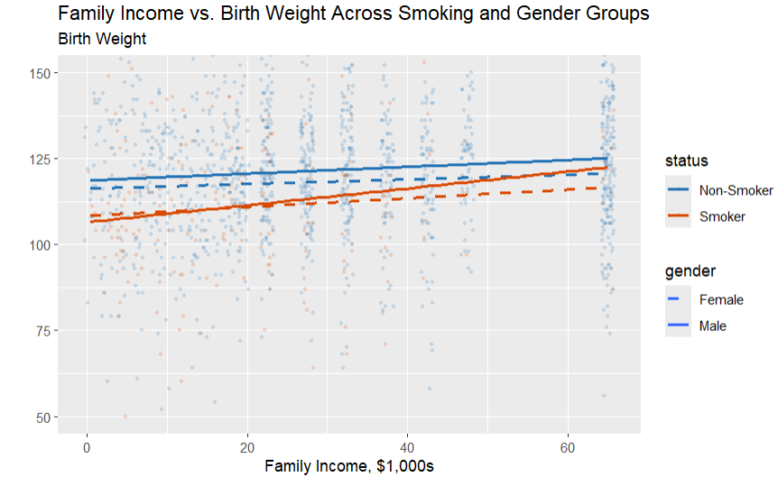

Plot to recreate

**Recreate something similar to the above graph showing the relationship of `bwght` and `faminc` across the different levels of `treat` and `male` (i.e., whether the mother smoked during pregnancy and whether the child was male or female). Then, discuss what you observe. Is there one combination of `treat` and `male` levels that appears to particularly strengthen the relationship between `faminc` and `bwght`? Then consider the data ethics concerns present in such a question. Should we make these sort of generalized statements with data? What do we not know about this dataset that we might want to learn before making any sort of general inference about the population?**

Suggested response to analysis questions: The combination of smoker mother and male child seems to have the strongest effect on the strength of relationship between `faminc` and `bwght`. However, there is much to consider and keep in mind when considering this sort of data, and making this sort of inference. There is much we don’t know about this dataset, such as the bias of its creators, the ethical nature of its creation, and much more that can seriously influence the reliability and interpretability of the dataset. So we should proceed with extreme care, and with knowledge of the limited nature of the inferences available to us, when examining data such as this. We would want to know a lot about the research and data collection methodology, the data ethics intentions of the dataset creators, and the overall sociological implications of the dataset in order to make more concrete inferences. And, importantly, we always want to keep respect and humanity at the top of mind when considering statistics that reflect real people.

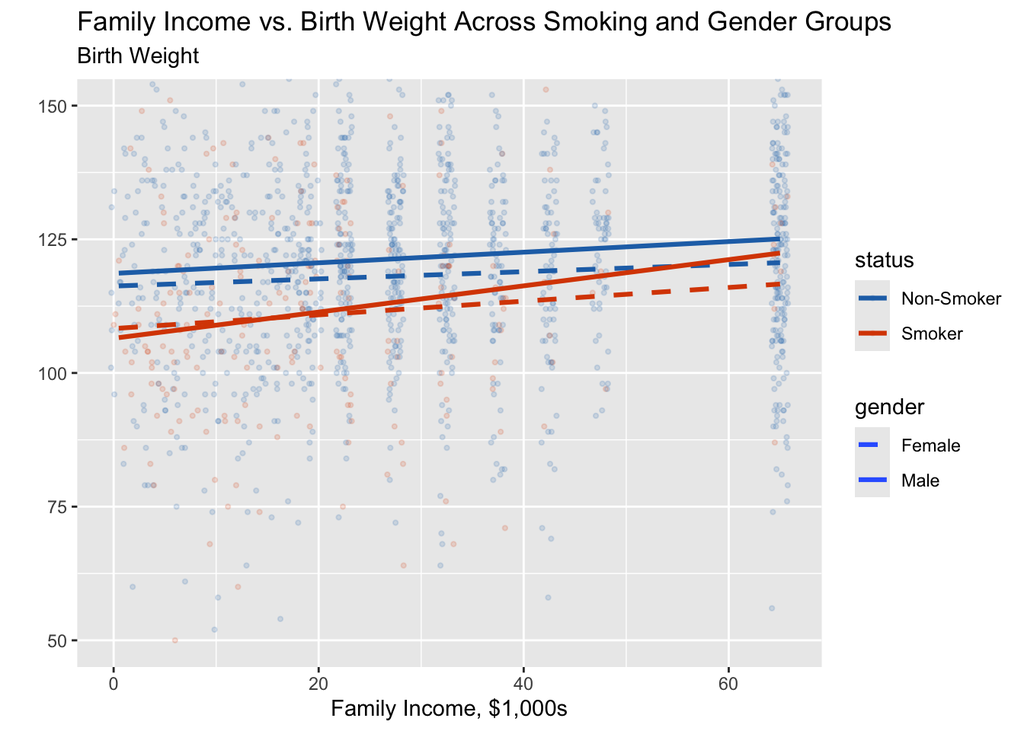

```r
data |>
  mutate(
    status = factor(treat, levels = c(0,1), labels = c("Non-Smoker", "Smoker")),
    gender = factor(male, levels = c(0,1), labels = c("Female", "Male"))
  ) |>
  ggplot(aes(x = faminc, y = bwght,
             color = status,
             linetype = gender)) +
  geom_jitter(alpha = 0.15, size = 0.8, width = 0.8, height = 0) +
  geom_smooth(method = lm, se = FALSE, linewidth = 1.1) +
  scale_color_manual(values = c("Non-Smoker" = "#2171b5", "Smoker" = "#d94801")) +
  scale_linetype_manual(values = c("Female" = "dashed", "Male" = "solid")) +
  labs(title = "Family Income vs. Birth Weight Across Smoking and Gender Groups",
       x = "Family Income, $1,000s",
       y = "",
       subtitle = "Birth Weight") +
  coord_cartesian(ylim = c(50, 150))
```

### Question 8: Inference Using Model Validation

**For this question, we are interested in the difference between the `bwght` of children whose mother did smoke and the `bwght` of children whose mother did not smoke. Specifically, we want to investigate the relative normality of each subset of data. State your conclusions from an examination of both plots. You may want to discuss the following, along with more general conclusions about the effects of smoking on `bwght`: does either subset of the data appear to be normally distributed? Is one more closely adherent to the normal distribution than the other? Why might that be? Is it possible that other lifestyle factors influencing `bwght` differ more among one group than the other (hint: look at your created table above and think about the differences in other lifestyle facts)?**

Suggested response to analysis questions: The q-q plot for smokers seems to contain less variation from the normal line, indicating that that subset may be more normally distributed. The q-q plot for non-smokers seems to indicate that there is a greater number of children of non-smokers being born at lower-than-expected weights. This could possibly be due to greater lifestyle similarities among smokers than among non-smokers, as smoking could be a unifying characteristic that leads to greater overall similarity in outcomes like child birth weight. However, this is just a possibility, and more sophisticated and ethical investigation would need to be done to make any firm conclusions here.

**Tip**

To compare relative normality, you’ll need to use q-q plots. Look at the documentation for those ggplot geoms for help!

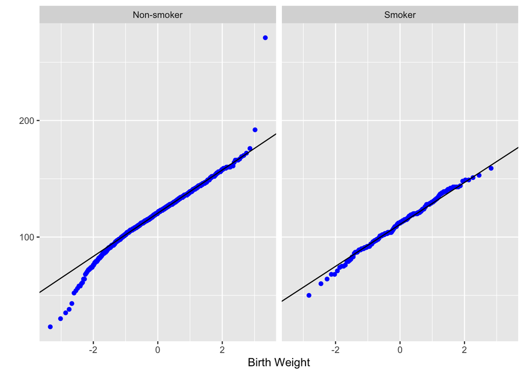

```r
# generating both q-q plots

data |>
  mutate(treat = factor(treat, labels = c("Non-smoker", "Smoker"))) |>
  ggplot(aes(sample = bwght)) +
  geom_qq(color = "blue") +
  geom_qq_line() +
  facet_wrap(~ treat) +
  labs(x = "Birth Weight", y = "")
```